# Effects

April Peterson

09 January 2020

# Cell Quality Effects

> Main points
1. There is a positive relationship with quality and MLH1 count (better cells have more MLH1)
2. The effect of Quality on mean MLH1 count is larger in males

> Open quesitons
- Are quality score less accurate/consistant for females?
- Should I weight mouse COs averages by the quality ratio?
- Exclude lowest quality cells in males, but keep them in female dataset?
- Does the effect for males still hold when Q5 cells are removed?

The the plots below, each point is a single mouse’s mean MLH1 count per cell across each quality score bin.

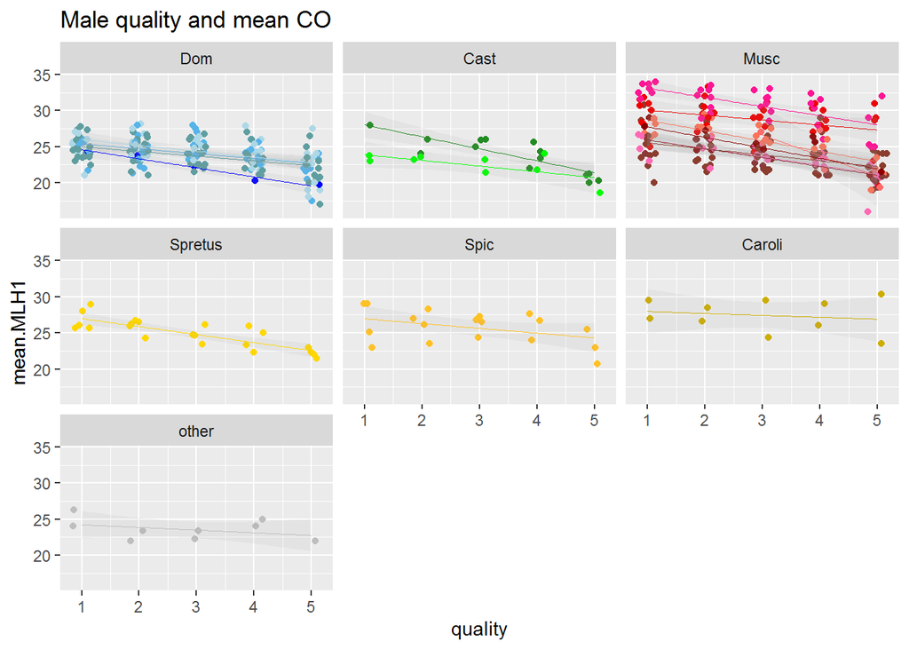

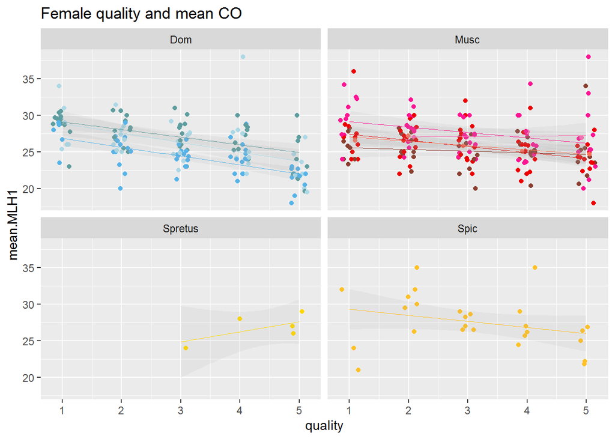

These plots show that generally there is a positive relationship between good quality and more MLH1 counts.

## Cell Quality effect on SC

In progress. Examine image quality or other scores to test how well the python scripts segment the SC area for all the images.

The mouse 22jun15_G_m2 has strange pattern, investigate the Python SC outputs. Some of the pattern goes away when redo.crop is set to equal ‘no’.

# Age Effect (male)

> Main Points
1. Weak evidence for age effect on MLH1 counts for male mice.
- Dom, no significant effects for age.
- Musc low, no significant effect for strain or age.
- Musc high, no significant age effects on mean CO count

My previous dataset showed age effect for SKIVE males due to unbalanced data. There were only 3 mice of 7,16, and 41 weeks. The models using this dataset had signifcant age effects. The updated data set now has ~4 mice of 7 weeks and no significant age effect.

I tested the age effects with 3 sets of models, for 3 groupings of mice: dom, musc.high and musc.low

$$mouse .mean CO \sim age + strain + \varepsilon$$

|  | Estimate | Std. Error | t value | Pr(>\|t\|) |
| --- | --- | --- | --- | --- |
| (Intercept) | 24.554128 | 0.397076 | 61.837337 | 0.000000 |
| age.weeks | -0.008739 | 0.016119 | -0.542127 | 0.591736 |
| strain.xG | -0.392589 | 0.436192 | -0.900037 | 0.375269 |
| strain.xLEW | 0.742300 | 0.586067 | 1.266578 | 0.215052 |

|  | Estimate | Std. Error | t value | Pr(>\|t\|) |
| --- | --- | --- | --- | --- |
| (Intercept) | 25.014890 | 0.892962 | 28.013379 | 0.000000 |
| age.weeks | -0.068806 | 0.038075 | -1.807131 | 0.089581 |
| strain.xKAZ | 0.144027 | 0.966632 | 0.148999 | 0.883416 |
| strain.xTOM | 2.041273 | 2.829428 | 0.721444 | 0.481047 |
| strain.xAST | 4.821212 | 2.739441 | 1.759926 | 0.097522 |

|  | Estimate | Std. Error | t value | Pr(>\|t\|) |
| --- | --- | --- | --- | --- |
| (Intercept) | 30.053518 | 0.442930 | 67.851561 | 0.000000 |
| age.weeks | -0.011246 | 0.023069 | -0.487479 | 0.632966 |
| strain.xMSM | 1.964503 | 0.585341 | 3.356170 | 0.004330 |
| strain.xSKIVE | -2.827539 | 0.543658 | -5.200947 | 0.000108 |

The plot below shows mouse averages as single points, showing the mean MLH1 and age in weeks. The lines and shading show the smoothed lm for each strain.

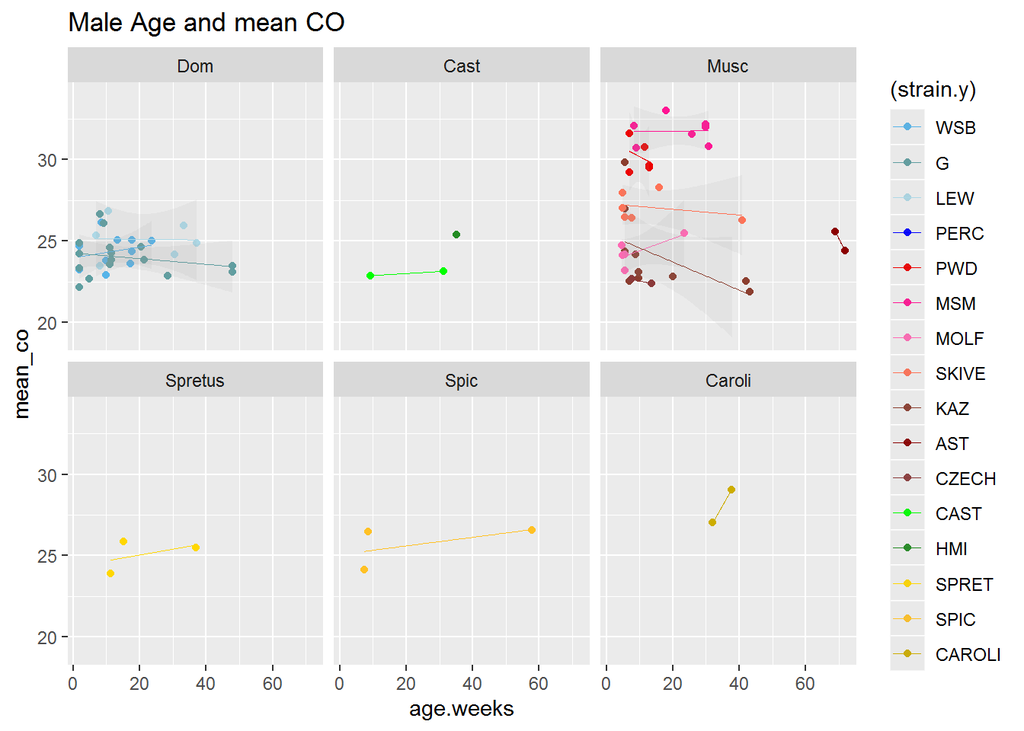

The models and mostly flat slopes indecate that there isn’t a strong age effect on MLH1 for these mice. (there might be a KAZ male outlier (10jul19_KAZ_m3), double check this). Change the colors for KAZ, TOM, AST, and CZECH they’re too similar.

While many slopes are different than 0, I am not convinced there is a clear age effect. Most strains don’t have more than 2 ages. I will double check some of these mice and check a general linear model.

# Age Effect (female)

Female ages most logically group into neonate or embryo, so I choose to apply a logistic regression to test for age effects. Not all strains have both embryo and neonate female samples, so just, WSB, G, LEW, and PWD are examined.

> Main Point
- MLH1 counts don’t differ between neonates and embryos

Below are the tests for the model (can CO number predict the age stage). I ran these comparisons for cell count and mouse averages. The plots show the points and smoothed curves with age on the y axis, 0 = embryo and 1 = neonate.

$$Age .Stage \sim CO .number$$

```
##               Estimate Std. Error   z value   Pr(>|z|)
## (Intercept) -2.3674068 1.49677975 -1.581667 0.11372566
## nMLH1.foci   0.1102284 0.06251089  1.763347 0.07784204
```

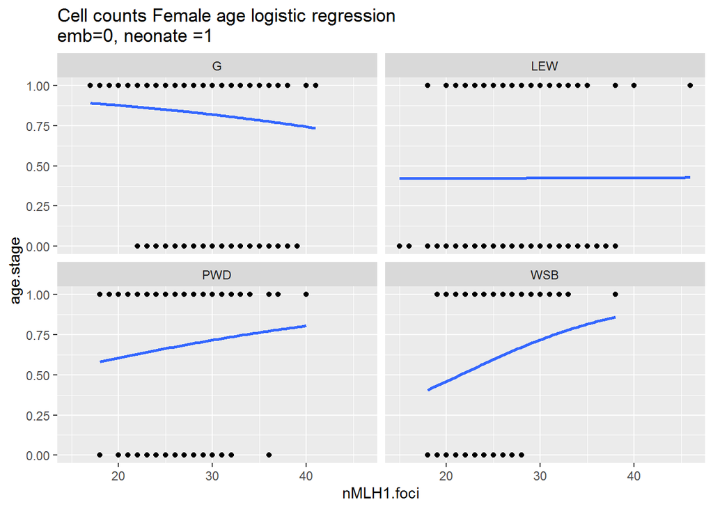

```
##               Estimate Std. Error   z value  Pr(>|z|)
## (Intercept) -4.1264410  4.0810987 -1.011110 0.3119636
## mean_co      0.1721114  0.1556258  1.105931 0.2687563
```

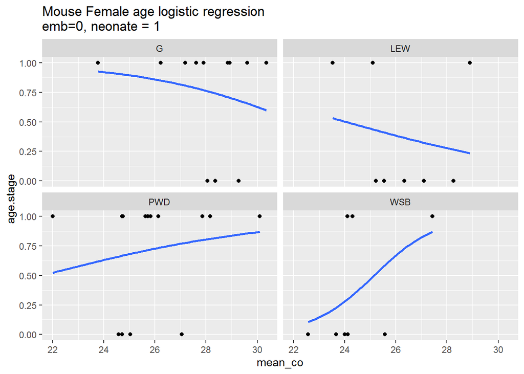

The mouse curves are more slanted, but the logistic regressions are not significant. None of the indiviual strains had significant p values when compared by themselves.

# Room effect

When this project was started the main mouse room for vendor purchased mice was Biotech. The mouse room changed in summer 2017. The Gough mice were always housed in Charmony. Of the final data set there are three strains had mice housed in different rooms; WSB, LEW, and MSM. (This data might not balanced and there are limited comparisons.)

The main questions to address in this section: is there a significant GxE effect due to room?

> Main Points
- There is some evidence for room effect on MLH1 counts per cell for WSB and LEW female and LEW and MSM male.
- No support of room effect for mouse means.

For the cell counts of MLH1, Two of three are in the same direction. Sample size might be having an effect.

There might be more mice/data that can be added to these tests, need to comfirm the move date and verify with lab note book.

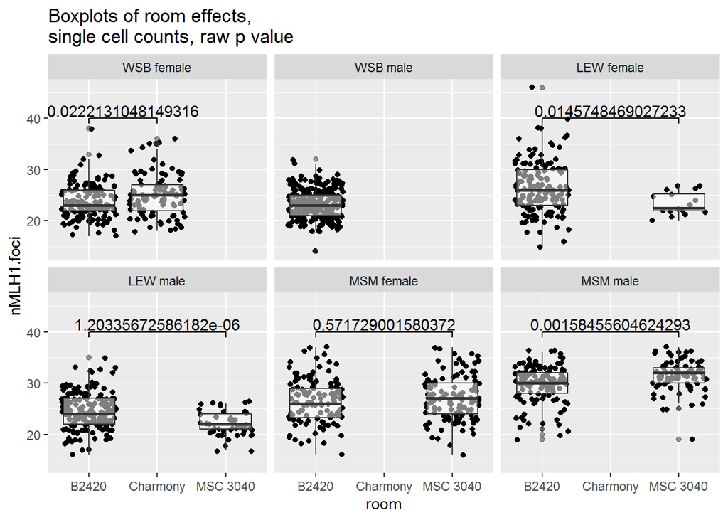

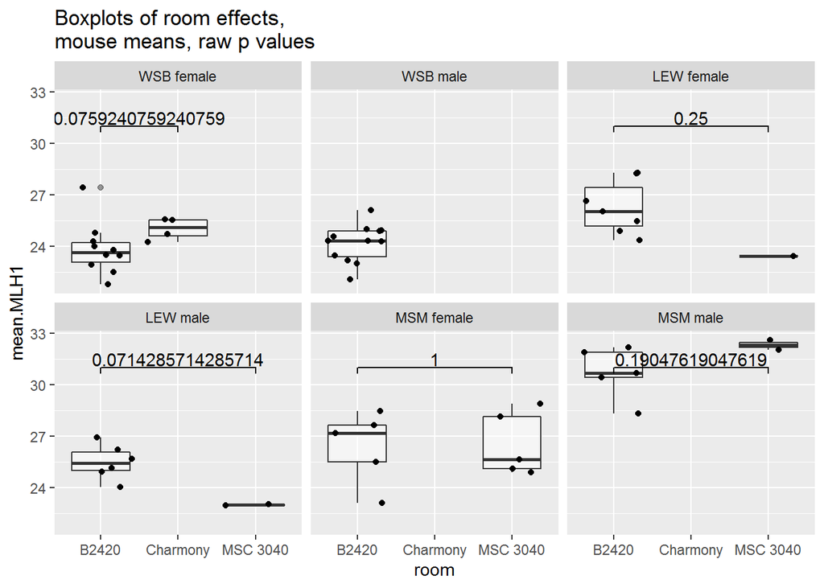

The brackets in the plots above reflect the output of ‘compare_means()’ which uses a wilcox.test. I double checked the wilcox p values for wilcox.test and compare_means, they’re similar.

There are significant room effects in the cell level data set. This effect decreases when comparing the mouse level means.

# Maternal Age effect

> Main Point
- Qualitatively, it doesn’t appear that there is a maternal age effect, but these data are underpowered.

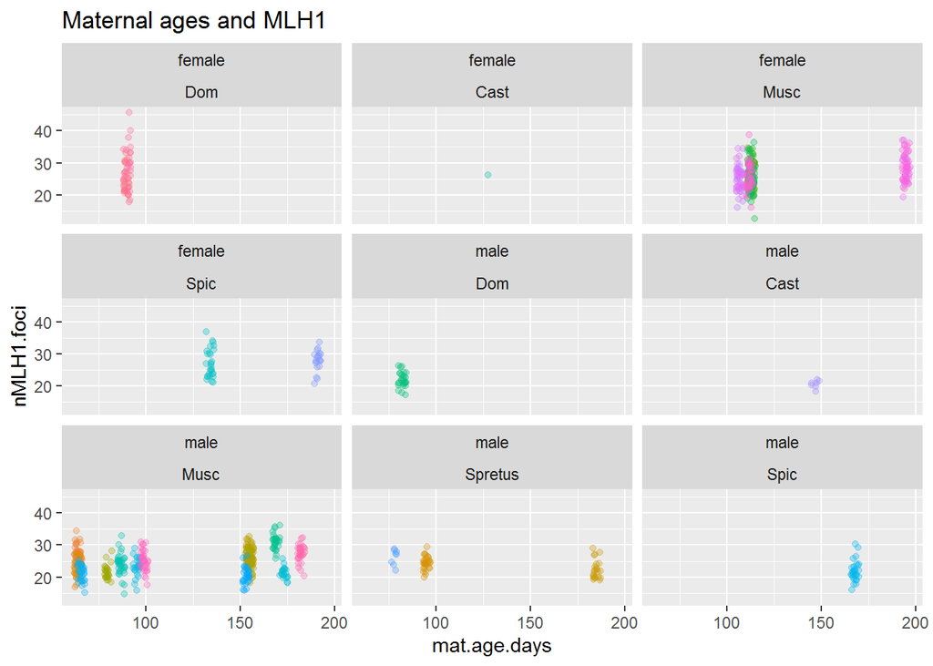

For the topics below, Maternal age, litter and dissection effect are all related, I need to outline/distinguish how and decide if these are worth further investigation.

## Litter effect

Compare female spreads made on the same day, but from different mothers/litters.

```r
#compile this data set
```

## Dissection spread Effect

Plotting euth date and mean CO number.

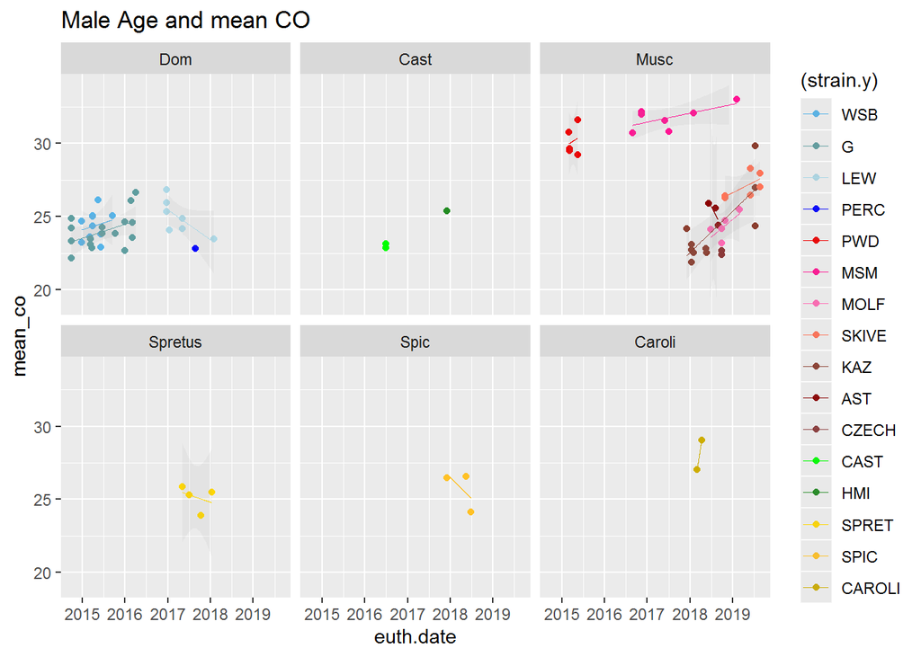

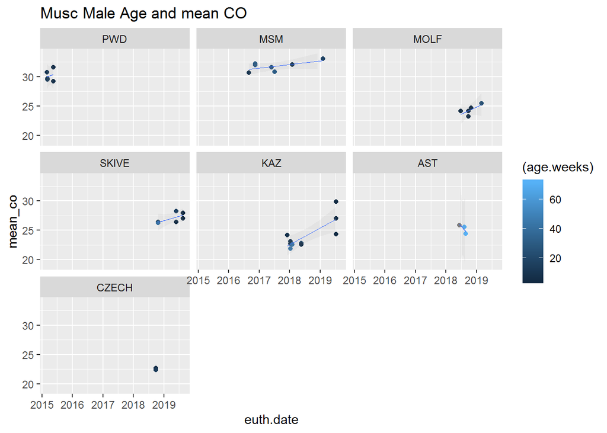

[figure not shown]

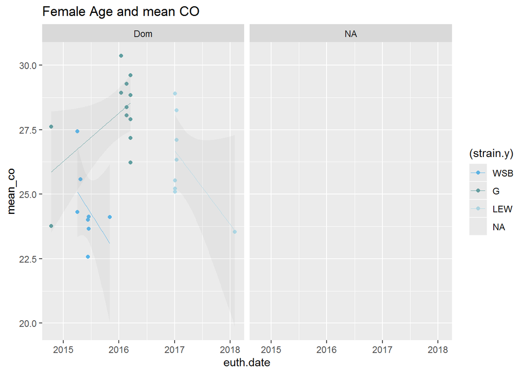

### Total SC

Testing the effects of mean total SC per mouse with when they were dissected. This is mean to be a follow up to peromyscus findings, Where summer caught mice had lower SC area per cell, compared to winter and fall caught. But there were few data points.

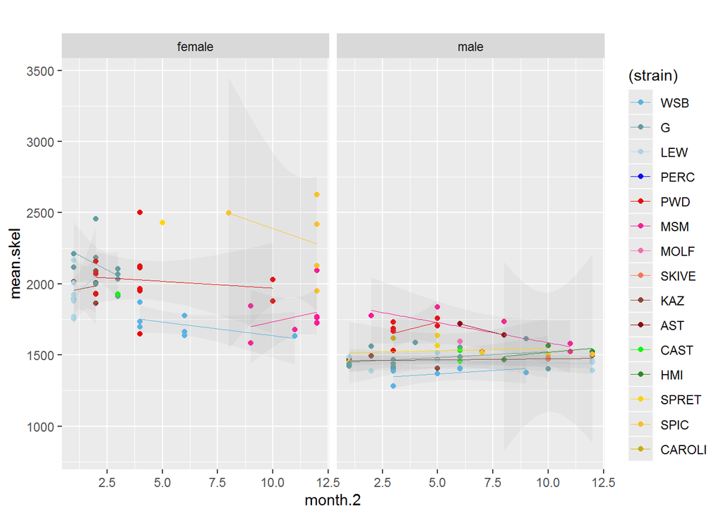

So, there doesn’t seem to be an effect of month dissected on SC area across mice. This might be the start of testing for ‘technical effects / humidity effects’. BUT, I don’t really have month by month dissections of mice of the same age, etc.

For mice strains that have a similar MLH1 level (control for strain MLH1 effect), check if a month effect for MLH1 count (as seen in Peromyscus).

# Stain Effect

At least 3 slides were made per mouse and I rarely included slides from the same mouse when running the statining protocol. Different staining batch might have effects on the background noise and brightness of the MLH1 foci (these could also be affected by post processing of images to a lesser extent). A siginificant stain effect would indecate technical error / I wasn’t consistant in running the staining protocol).

**collect data set for mice with multiple spreads (sp1, sp2 make ddply table that counts a gerp for ‘sp1’, sp2, ect)**

These data might also be underpowered, since I mostly used 1 spread and it was rare for me to collect over ~20 cells from multiple spreads from the same mouse. Compare observations from the same mouse, but different MLH1 stains. First need to identify data that can be used.

```r
#compile this dataset
```